# **Applied Statistics Project Solution**

# **PART A**

```python
# No. of people who planned to purchase and actually placed an order = 400
# Total No. of People = 2000
Joint_prob = 400 / 2000
print('Joint probability of the people who planned to purchase and actually placed an order = %f' %Joint_prob)
```

```
Joint probability of the people who planned to purchase and actually placed an order = 0.200000
```

```python
# P(Planned_and_Ordered | Planned) = P(Planned AND Ordered)/P(Planned)
# P(Planned AND Ordered) = 400/2000
# P(Planned) = 500/2000

Prob = (400/2000)/(500/2000)
print('Joint probability of the people who planned to purchase and actually placed an order,given that people planned to purchase  = %f' %Prob)
```

```
Joint probability of the people who planned to purchase and actually placed an order,given that people planned to purchase  = 0.800000
```

**2.** An electrical manufacturing company conducts quality checks at specified periods on the products it manufactures. Historically, the failure rate for the manufactured item is 5%. Suppose a random sample of 10 manufactured items is selected. Answer the following questions.

```python
import numpy as np
import pandas as pd
import scipy.stats as stats
import matplotlib.pyplot as plt

# Failure rate for manufactured item is 5%
p =  0.05

# Random sample size
n =  10

# Define an array
k =  np.arange(0,11)

array = stats.binom.pmf(k,n,p)

print(array)
```

```
[5.98736939e-01 3.15124705e-01 7.46347985e-02 1.04750594e-02
 9.64808106e-04 6.09352488e-05 2.67259863e-06 8.03789062e-08
 1.58642578e-09 1.85546875e-11 9.76562500e-14]
```

**2A.** Probability that none of the items are defective?

```python
print('Probability that none of the items are defective = %f' %array[0])
```

```
Probability that none of the items are defective = 0.598737
```

**2B.** Probability that exactly one of the items is defective?

```python
print('Probability that exactly one of the items is defective = %f' %array[1])
```

```
Probability that exactly one of the items is defective = 0.315125
```

**2C.** Probability that two or fewer of the items are defective?

```python
cummulative_prob = stats.binom.cdf(k,n,p)
print(cummulative_prob)
print('\nProbability that  two or fewer of the items are defective = %f' %cummulative_prob[2])
```

```
[0.59873694 0.91386164 0.98849644 0.9989715  0.99993631 0.99999725
 0.99999992 1.         1.         1.         1.        ]

Probability that  two or fewer of the items are defective = 0.988496
```

**2D.** Probability that three or more of the items are defective ?

```python
z = 1- cummulative_prob[2]
print('Probability that three or more of the items are defective = %f' %z)
```

```
Probability that three or more of the items are defective = 0.011504
```

**3.** A car salesman sells on an average 3 cars per week.

**3A.** What is Probability that in a given week he will sell some cars?

```python
# Using Poisson Distribution here
# lambda = 3
# We need to find probability of selling some cars i.e. P(X >= 0) = 1 - P(X = 0)

rate     = 3
n        = np.arange(0,20)
poisson  = stats.poisson.cdf(n,rate)
P        = 1 - poisson[0]
print('Probability that the car salesman sells some cars = %.4f' % P)
```

```
Probability that the car salesman sells some cars = 0.9502
```

**3B.** What is Probability that in a given week he will sell 2 or more but less than 5 cars?

```python
# P(X >=4) is P1 the probability that the car salesman sells more than 4 cars
P1 = poisson[4]
# P(X >=1) is P2 the probability that the car salesman sells more than 1 car
P2 = poisson[1]
# P is the probablity that the car salesman will sell more than 2 but less than 5 cars
P = P1 - P2
print('Probability that the car salesman will sell more than 2 but less than 5 cars = %.4f' % P)
```

```
Probability that the car salesman will sell more than 2 but less than 5 cars = 0.6161
```

**3C.** Plot the poisson distribution function for cumulative probability of cars sold per-week vs number of cars sold per week.

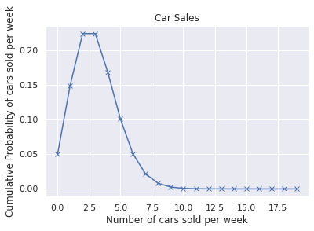

```python
poisson = stats.poisson.pmf(n,rate)
plt.plot(n,poisson,'x-')
plt.title('Car Sales')
plt.xlabel('Number of cars sold per week')
plt.ylabel('Cumulative Probability of cars sold per week')
plt.show()
```

**4.** Accuracy in understanding orders for a speech based bot at a restaurant is important for the Company X which has designed, marketed and launched the product for a contactless delivery due to the COVID-19 pandemic. Recognition accuracy that measures the percentage of orders that are taken correctly is 86.8%. Suppose that you place an order with the bot and two friends of yours independently place orders with the same bot. Answer the following questions.

Solution Approach: Let's check first whether we satisfy the assumptions of the binomial distribution.

1. There are only two possible outcomes (success or failure) for each trial – Order placed is correct or not (yes or no).
2. Number of trials (n) is fixed - There are 3 orders in the sample.
3. Each trial is independent of the other trials - Given in statement
4. The probability of success (p) is the same for each trial - The probability of success for each visitor is 0.868

The probability function of Binomial Distribution provides the probability for x number of successes from n trials where p is the probability of success

Here, we know that: n = 3, p = 0.868, q = 1 - 0.868 = 0.132, X = 3

We will use binom.pmf() to calculate this probability function which provides the probability for the number of orders (out of n=3) that will be correctly placed.

```python
# declare the sample size in variable n which represents the number of orders
n = 3
# declare p which represents the probability of success, i.e., the probability that an order is taken correctly
p = 0.868
# declare different possible number of orders selected in a numpy array
k = np.arange(0,4)
k
```

```
array([0, 1, 2, 3])
```

```python
# import the required function
from scipy.stats import binom

# use the binom.pmf() function to generate the probability distribution
binomial = binom.pmf(k=k, n=n, p=p)
binomial
```

```
array([0.00229997, 0.0453721 , 0.2983559 , 0.65397203])
```

**4A.** What is the probability that all three orders will be recognised correctly?

```python
# The last element of this binomial array represents the probability when the number of successes is 3
print('Probability that all three orders will be recognised correctly = %.4f' %binomial[3])
```

```
Probability that all three orders will be recognised correctly = 0.6540
```

**4B.** What is the probability that none of the three orders will be recognised correctly?

```python
# The 0th element of this binomial array represents the probability when the number of successes is 0
print('Probability that none of the three orders will be recognised correctly = %.4f' %binomial[0])
```

```
Probability that none of the three orders will be recognised correctly = 0.0023
```

**4C.** What is the probability that at least two of the three orders will be recognised correctly?

```python
# Now, we are interested in knowing the probability of atleast 2 of 3 orders recognised correctly.
# Here, we need to calculate the probability for P(X >=2). CDF is used to calculate the cumulative probability.

# calculate cdf
P = 1 - binom.cdf(k=1, n=n, p=p)

print('Probability that at least two of the three orders will be recognised correctly = %.4f' %P)

# It can also be calculated using P(X=2) + P(X=3) = binomial[2] + binomial[3] = 0.952327936
```

```
Probability that at least two of the three orders will be recognised correctly = 0.9523
```

**5.** Explain 1 real life industry scenario (other than the ones mentioned above) where you can use the concepts learnt in this module of Applied Statistics to get data driven business solution.

For a Real Life example, we can consider the example of IT companies. The HR, Transport and IT team tracks people movement,login hours, checkin/check out, WFH, online_hours, performance, availability, Gender, Maternity Status, websites visited like naukri.com, etc. Using the above set of data points, lots of insights can be derived out of it like:

1. Employee login and logoff time
2. Loyal to the company to check on Attrition.
3. Maternity/Religion of the employee can be used to predict leaves.
4. Track the trend/Productivity of Employee working remotely or from office or use of transport.
5. Productivity of the employee

Using both descriptive as well as inference based statistics,more information or analysis can be done which will help Management to take appropriate call.

Typical example is avoid plannning a project release as per festival dates like Diwali/Christmas.

Also, drawing relation between Websites visited like job portals and login hours or WFH can help control attrition. Management can take proactive actions to retain the employee.

# **PART B**

DOMAIN: Sports

CONTEXT: Company X manages the men's top professional basketball division of the American league system. The dataset contains information on all the teams that have participated in all the past tournaments. It has data about how many baskets each team scored, conceded, how many times they came within the first 2 positions, how many tournaments they have qualified, their best position in the past, etc.

DATA DESCRIPTION: Basketball.csv - The data set contains information on all the teams so far participated in all the past tournaments.

DATA DICTIONARY:

1. Team: Team’s name
2. Tournament: Number of played tournaments.
3. Score: Team’s score so far.
4. PlayedGames: Games played by the team so far.
5. WonGames: Games won by the team so far.
6. DrawnGames: Games drawn by the team so far.
7. LostGames: Games lost by the team so far.
8. BasketScored: Basket scored by the team so far.
9. BasketGiven: Basket scored against the team so far.
10. TournamentChampion: How many times the team was a champion of the tournaments so far.
11. Runner-up: How many times the team was a runners-up of the tournaments so far.
12. TeamLaunch: Year the team was launched on professional basketball.
13. HighestPositionHeld: Highest position held by the team amongst all the tournaments played.

PROJECT OBJECTIVE: Company’s management wants to invest on proposals on managing some of the best teams in the league. The analytics department has been assigned with a task of creating a report on the performance shown by the teams. Some of the older teams are already in contract with competitors. Hence Company X wants to understand which teams they can approach which will be a deal win for them.

```python
import pandas as pd
import numpy as np
import matplotlib.pyplot as plt
import seaborn as sns
%matplotlib inline
```

## **1.** Read the data set, clean the data and prepare final dataset to be used for analysis.

```python
data = pd.read_csv("DS - Part2 - Basketball.csv")
```

```python
data.info()
```

```
<class 'pandas.core.frame.DataFrame'>
RangeIndex: 61 entries, 0 to 60
Data columns (total 13 columns):
 #   Column               Non-Null Count  Dtype
---  ------               --------------  -----
 0   Team                 61 non-null     object
 1   Tournament           61 non-null     int64
 2   Score                61 non-null     object
 3   PlayedGames          61 non-null     object
 4   WonGames             61 non-null     object
 5   DrawnGames           61 non-null     object
 6   LostGames            61 non-null     object
 7   BasketScored         61 non-null     object
 8   BasketGiven          61 non-null     object
 9   TournamentChampion   61 non-null     object
 10  Runner-up            61 non-null     object
 11  TeamLaunch           61 non-null     object
 12  HighestPositionHeld  61 non-null     int64
dtypes: int64(2), object(11)
memory usage: 6.3+ KB
```

```python
data.head()
```

|  | Team | Tournament | Score | PlayedGames | WonGames | DrawnGames | LostGames | BasketScored | BasketGiven | TournamentChampion | Runner-up | TeamLaunch | HighestPositionHeld |
| --- | --- | --- | --- | --- | --- | --- | --- | --- | --- | --- | --- | --- | --- |
| 0 | Team 1 | 86 | 4385 | 2762 | 1647 | 552 | 563 | 5947 | 3140 | 33 | 23 | 1929 | 1 |
| 1 | Team 2 | 86 | 4262 | 2762 | 1581 | 573 | 608 | 5900 | 3114 | 25 | 25 | 1929 | 1 |
| 2 | Team 3 | 80 | 3442 | 2614 | 1241 | 598 | 775 | 4534 | 3309 | 10 | 8 | 1929 | 1 |
| 3 | Team 4 | 82 | 3386 | 2664 | 1187 | 616 | 861 | 4398 | 3469 | 6 | 6 | 1931to32 | 1 |
| 4 | Team 5 | 86 | 3368 | 2762 | 1209 | 633 | 920 | 4631 | 3700 | 8 | 7 | 1929 | 1 |

```python
# Replace all '-' chars with 0
data = data.replace(to_replace = "-", value = 0)
```

```python
# Check if any Entry with Tournament > 1 but PlayedGames is 0. This is a Junk Entry. Need to drop the row.
data.drop(data[(data['Tournament'] != 0) & (data['PlayedGames'] == 0)].index, axis = 0, inplace = True)
```

```python
# Remove all rows with NULL values
data.dropna(inplace = True)
```

```python
# Check for duplicate entries and remove them
data.drop_duplicates(subset=['Team'], inplace=True)
```

```python
# Reset index in case few rows get deleted in between.
data.reset_index(drop=True, inplace = True)
```

```python
data.info()
```

```
<class 'pandas.core.frame.DataFrame'>
RangeIndex: 60 entries, 0 to 59
Data columns (total 13 columns):
 #   Column               Non-Null Count  Dtype
---  ------               --------------  -----
 0   Team                 60 non-null     object
 1   Tournament           60 non-null     int64
 2   Score                60 non-null     object
 3   PlayedGames          60 non-null     object
 4   WonGames             60 non-null     object
 5   DrawnGames           60 non-null     object
 6   LostGames            60 non-null     object
 7   BasketScored         60 non-null     object
 8   BasketGiven          60 non-null     object
 9   TournamentChampion   60 non-null     object
 10  Runner-up            60 non-null     object
 11  TeamLaunch           60 non-null     object
 12  HighestPositionHeld  60 non-null     int64
dtypes: int64(2), object(11)
memory usage: 6.2+ KB
```

```python
# Clean up the date column 'TeamLaunch' by reading first 4 digits to store only the launch year. We dont need the rest of data
data['TeamLaunch'] = data['TeamLaunch'].str.extract(r'^(\d{4})', expand=False)
```

```python
# Convert all columns with object datatypes to integer except 'Team' Column.
data[data.columns[1:]] = data[data.columns[1:]].astype('int64')
```

```python
data.head()
```

|  | Team | Tournament | Score | PlayedGames | WonGames | DrawnGames | LostGames | BasketScored | BasketGiven | TournamentChampion | Runner-up | TeamLaunch | HighestPositionHeld |
| --- | --- | --- | --- | --- | --- | --- | --- | --- | --- | --- | --- | --- | --- |
| 0 | Team 1 | 86 | 4385 | 2762 | 1647 | 552 | 563 | 5947 | 3140 | 33 | 23 | 1929 | 1 |
| 1 | Team 2 | 86 | 4262 | 2762 | 1581 | 573 | 608 | 5900 | 3114 | 25 | 25 | 1929 | 1 |
| 2 | Team 3 | 80 | 3442 | 2614 | 1241 | 598 | 775 | 4534 | 3309 | 10 | 8 | 1929 | 1 |
| 3 | Team 4 | 82 | 3386 | 2664 | 1187 | 616 | 861 | 4398 | 3469 | 6 | 6 | 1931 | 1 |
| 4 | Team 5 | 86 | 3368 | 2762 | 1209 | 633 | 920 | 4631 | 3700 | 8 | 7 | 1929 | 1 |

```python
# Make sure all columns except Team is of integer data type
data.info()
```

```
<class 'pandas.core.frame.DataFrame'>
RangeIndex: 60 entries, 0 to 59
Data columns (total 13 columns):
 #   Column               Non-Null Count  Dtype
---  ------               --------------  -----
 0   Team                 60 non-null     object
 1   Tournament           60 non-null     int64
 2   Score                60 non-null     int64
 3   PlayedGames          60 non-null     int64
 4   WonGames             60 non-null     int64
 5   DrawnGames           60 non-null     int64
 6   LostGames            60 non-null     int64
 7   BasketScored         60 non-null     int64
 8   BasketGiven          60 non-null     int64
 9   TournamentChampion   60 non-null     int64
 10  Runner-up            60 non-null     int64
 11  TeamLaunch           60 non-null     int64
 12  HighestPositionHeld  60 non-null     int64
dtypes: int64(12), object(1)
memory usage: 6.2+ KB
```

## **2.** Perform detailed statistical analysis and EDA using univariate, bi-variate and multivariate EDA techniques to get data driven insights on recommending which teams they can approach which will be a deal win for them. Also as a data and statistics expert you have to develop a detailed performance report using this data.

```python
# Lets add few columns by using existing data
# Win_Percent : Percentages of games team won.
# Lost_Percent: Percentages of games team lost.
# Win_Ratio   : No. of games won/No. of games lost

# Add Win_Percent column to dataset
Win_Percent = data['WonGames'] / data['PlayedGames']
data.insert(loc=13, column='Win_Percent', value=Win_Percent)

# Add Lost_Percent column to dataset
Lost_Percent = data['LostGames'] / data['PlayedGames']
data.insert(loc=14, column='Lost_Percent', value=Lost_Percent)

# Add Win Ratio column to dataset
Win_Ratio = data['WonGames'] / data['LostGames']
data.insert(loc=15, column='Win_Ratio', value=Win_Ratio)

# Add Basket_Diff column to dataset
data['Basket_Diff']=data['BasketScored'] - data['BasketGiven']
```

```python
data.head()
```

|  | Team | Tournament | Score | PlayedGames | WonGames | DrawnGames | LostGames | BasketScored | BasketGiven | TournamentChampion | Runner-up | TeamLaunch | HighestPositionHeld | Win_Percent | Lost_Percent | Win_Ratio | Basket_Diff |
| --- | --- | --- | --- | --- | --- | --- | --- | --- | --- | --- | --- | --- | --- | --- | --- | --- | --- |
| 0 | Team 1 | 86 | 4385 | 2762 | 1647 | 552 | 563 | 5947 | 3140 | 33 | 23 | 1929 | 1 | 0.596307 | 0.203838 | 2.925400 | 2807 |
| 1 | Team 2 | 86 | 4262 | 2762 | 1581 | 573 | 608 | 5900 | 3114 | 25 | 25 | 1929 | 1 | 0.572411 | 0.220130 | 2.600329 | 2786 |
| 2 | Team 3 | 80 | 3442 | 2614 | 1241 | 598 | 775 | 4534 | 3309 | 10 | 8 | 1929 | 1 | 0.474751 | 0.296480 | 1.601290 | 1225 |
| 3 | Team 4 | 82 | 3386 | 2664 | 1187 | 616 | 861 | 4398 | 3469 | 6 | 6 | 1931 | 1 | 0.445571 | 0.323198 | 1.378630 | 929 |
| 4 | Team 5 | 86 | 3368 | 2762 | 1209 | 633 | 920 | 4631 | 3700 | 8 | 7 | 1929 | 1 | 0.437726 | 0.333092 | 1.314130 | 931 |

```python
data.info()
```

```
<class 'pandas.core.frame.DataFrame'>
RangeIndex: 60 entries, 0 to 59
Data columns (total 17 columns):
 #   Column               Non-Null Count  Dtype
---  ------               --------------  -----
 0   Team                 60 non-null     object
 1   Tournament           60 non-null     int64
 2   Score                60 non-null     int64
 3   PlayedGames          60 non-null     int64
 4   WonGames             60 non-null     int64
 5   DrawnGames           60 non-null     int64
 6   LostGames            60 non-null     int64
 7   BasketScored         60 non-null     int64
 8   BasketGiven          60 non-null     int64
 9   TournamentChampion   60 non-null     int64
 10  Runner-up            60 non-null     int64
 11  TeamLaunch           60 non-null     int64
 12  HighestPositionHeld  60 non-null     int64
 13  Win_Percent          60 non-null     float64
 14  Lost_Percent         60 non-null     float64
 15  Win_Ratio            60 non-null     float64
 16  Basket_Diff          60 non-null     int64
dtypes: float64(3), int64(13), object(1)
memory usage: 8.1+ KB
```

```python
data.corr()
```

|  | Tournament | Score | PlayedGames | WonGames | DrawnGames | LostGames | BasketScored | BasketGiven | TournamentChampion | Runner-up | TeamLaunch | HighestPositionHeld | Win_Percent | Lost_Percent | Win_Ratio | Basket_Diff |
| --- | --- | --- | --- | --- | --- | --- | --- | --- | --- | --- | --- | --- | --- | --- | --- | --- |
| Tournament | 1.000000 | 0.981258 | 0.998683 | 0.971749 | 0.989295 | 0.949350 | 0.974867 | 0.987781 | 0.589304 | 0.645924 | -0.599166 | -0.708002 | 0.819559 | -0.761297 | 0.763787 | 0.537743 |
| Score | 0.981258 | 1.000000 | 0.979687 | 0.997232 | 0.958090 | 0.878780 | 0.996634 | 0.943801 | 0.715014 | 0.764819 | -0.538542 | -0.669215 | 0.877385 | -0.809566 | 0.861685 | 0.677186 |
| PlayedGames | 0.998683 | 0.979687 | 1.000000 | 0.967486 | 0.993972 | 0.955925 | 0.969970 | 0.990020 | 0.575072 | 0.633101 | -0.581243 | -0.711065 | 0.813179 | -0.767913 | 0.757107 | 0.521147 |
| WonGames | 0.971749 | 0.997232 | 0.967486 | 1.000000 | 0.939416 | 0.851436 | 0.999312 | 0.925745 | 0.752904 | 0.797849 | -0.540421 | -0.647819 | 0.884278 | -0.802821 | 0.879755 | 0.718745 |
| DrawnGames | 0.989295 | 0.958090 | 0.993972 | 0.939416 | 1.000000 | 0.972786 | 0.942234 | 0.992479 | 0.503378 | 0.566021 | -0.570175 | -0.720248 | 0.774416 | -0.757461 | 0.705724 | 0.446869 |
| LostGames | 0.949350 | 0.878780 | 0.955925 | 0.851436 | 0.972786 | 1.000000 | 0.857843 | 0.985041 | 0.324025 | 0.391645 | -0.591571 | -0.726172 | 0.665366 | -0.655055 | 0.551702 | 0.249655 |
| BasketScored | 0.974867 | 0.996634 | 0.969970 | 0.999312 | 0.942234 | 0.857843 | 1.000000 | 0.931079 | 0.743847 | 0.791041 | -0.550150 | -0.648672 | 0.879124 | -0.795043 | 0.870959 | 0.710175 |
| BasketGiven | 0.987781 | 0.943801 | 0.990020 | 0.925745 | 0.992479 | 0.985041 | 0.931079 | 1.000000 | 0.471618 | 0.533448 | -0.608902 | -0.727323 | 0.757279 | -0.717092 | 0.672901 | 0.404389 |
| TournamentChampion | 0.589304 | 0.715014 | 0.575072 | 0.752904 | 0.503378 | 0.324025 | 0.743847 | 0.471618 | 1.000000 | 0.971533 | -0.286768 | -0.304307 | 0.765351 | -0.638581 | 0.917776 | 0.954675 |
| Runner-up | 0.645924 | 0.764819 | 0.633101 | 0.797849 | 0.566021 | 0.391645 | 0.791041 | 0.533448 | 0.971533 | 1.000000 | -0.317250 | -0.359191 | 0.801247 | -0.677121 | 0.932008 | 0.953671 |
| TeamLaunch | -0.599166 | -0.538542 | -0.581243 | -0.540421 | -0.570175 | -0.591571 | -0.550150 | -0.608902 | -0.286768 | -0.317250 | 1.000000 | 0.599679 | -0.491259 | 0.201751 | -0.361126 | -0.204151 |
| HighestPositionHeld | -0.708002 | -0.669215 | -0.711065 | -0.647819 | -0.720248 | -0.726172 | -0.648672 | -0.727323 | -0.304307 | -0.359191 | 0.599679 | 1.000000 | -0.737288 | 0.661382 | -0.571122 | -0.222614 |
| Win_Percent | 0.819559 | 0.877385 | 0.813179 | 0.884278 | 0.774416 | 0.665366 | 0.879124 | 0.757279 | 0.765351 | 0.801247 | -0.491259 | -0.737288 | 1.000000 | -0.851444 | 0.940757 | 0.742541 |
| Lost_Percent | -0.761297 | -0.809566 | -0.767913 | -0.802821 | -0.757461 | -0.655055 | -0.795043 | -0.717092 | -0.638581 | -0.677121 | 0.201751 | 0.661382 | -0.851444 | 1.000000 | -0.852218 | -0.609304 |
| Win_Ratio | 0.763787 | 0.861685 | 0.757107 | 0.879755 | 0.705724 | 0.551702 | 0.870959 | 0.672901 | 0.917776 | 0.932008 | -0.361126 | -0.571122 | 0.940757 | -0.852218 | 1.000000 | 0.884906 |
| Basket_Diff | 0.537743 | 0.677186 | 0.521147 | 0.718745 | 0.446869 | 0.249655 | 0.710175 | 0.404389 | 0.954675 | 0.953671 | -0.204151 | -0.222614 | 0.742541 | -0.609304 | 0.884906 | 1.000000 |

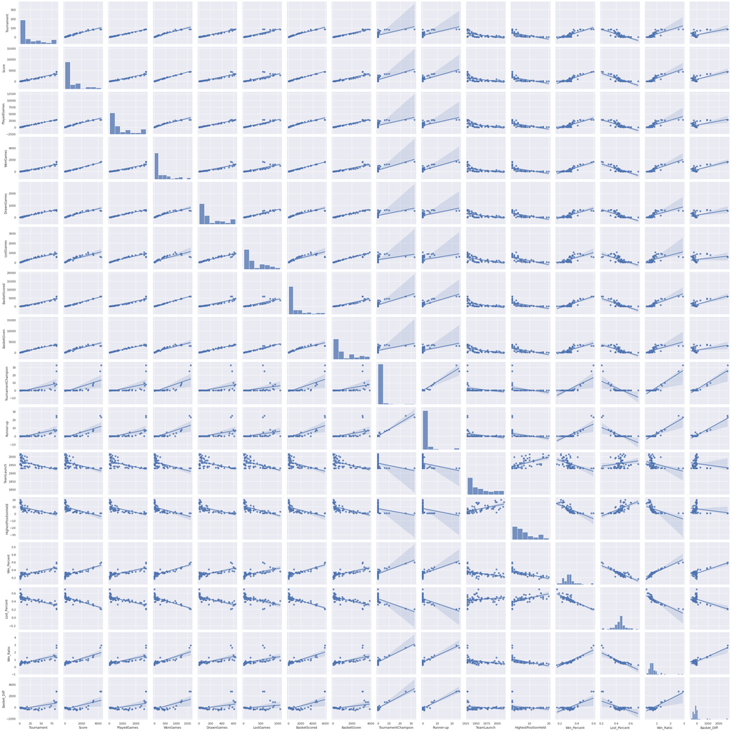

```python
import seaborn as sns
sns.pairplot(data, kind="reg")
plt.show()
```

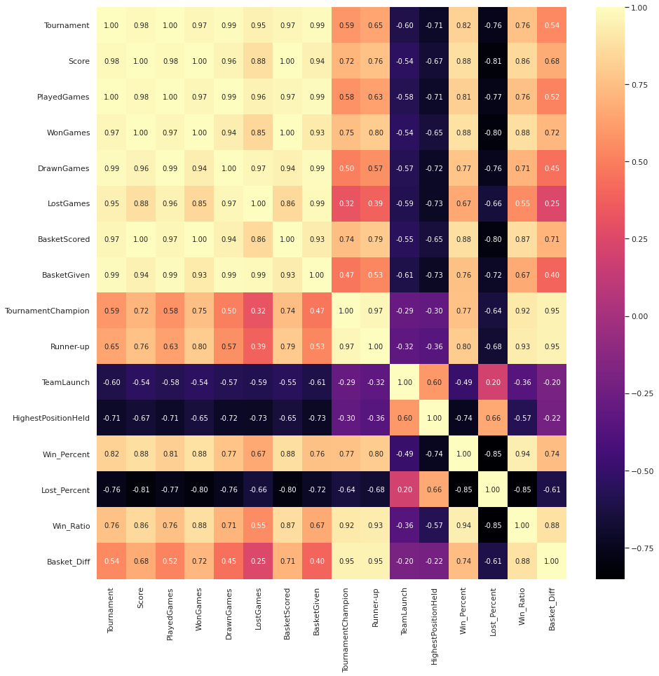

```python
fig,ax = plt.subplots(figsize=(15, 15))
sns.heatmap(data.corr(), ax=ax, annot=True, fmt= '.2f',cmap="magma")
plt.show()
```

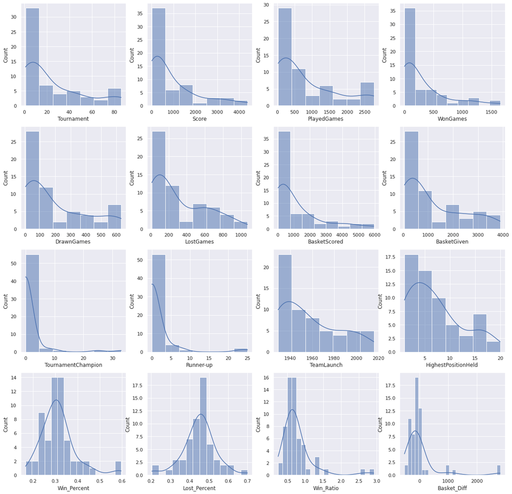

```python
# Distribution Plot
columns = ['Tournament','Score','PlayedGames','WonGames','DrawnGames','LostGames','BasketScored','BasketGiven','TournamentChampion','Runner-up','TeamLaunch','HighestPositionHeld', 'Win_Percent', 'Lost_Percent', 'Win_Ratio', 'Basket_Diff']
#  Categorical Data
a = 4  # number of rows
b = 4  # number of columns
c = 1  # initialize plot counter
fig = plt.figure(figsize=(20, 20))
for col in data[columns]:
    plt.subplot(a, b, c)
    sns.histplot(data=data, x = col, kde=True)
    c = c + 1

plt.show()
```

Win_Percent and Lost_Percent is kind of Normally distributed. Rest other columns are slightly right skewed except for *TournamentChampion* and *Runner-up*.

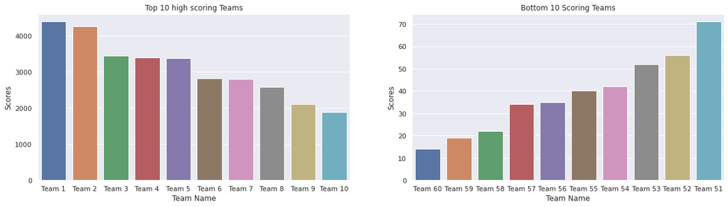

```python
# Top/Bottom 10 Goal Scoring Teams
fig, ax = plt.subplots(figsize=(20, 5))

score = data.sort_values(by=['Score'], ascending=False)
score = score.head(10)
plt.subplot(1, 2, 1)
sns.barplot(x = score['Team'], y = score['Score'])
plt.title('Top 10 high scoring Teams')
plt.ylabel('Scores')
plt.xlabel('Team Name')

score = data.sort_values(by=['Score'], ascending=True)
score = score.head(10)
plt.subplot(1, 2, 2)
sns.barplot(x = score['Team'], y = score['Score'])
plt.title('Bottom 10 Scoring Teams')
plt.ylabel('Scores' )
plt.xlabel('Team Name')

plt.show()
```

1. Team 1 and Team 2 have the highest score
2. Team 60 is the least scorer

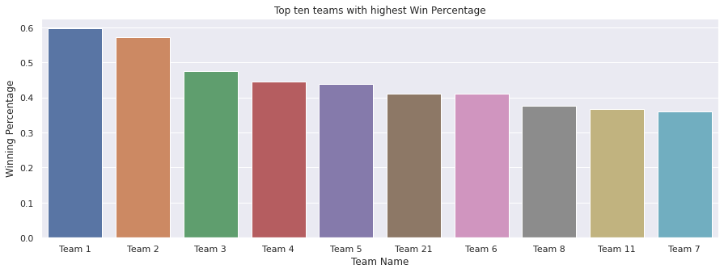

```python
# Top ten teams with highest Win %
Win_Percent = data.sort_values(by=['Win_Percent'], ascending=False)
Win_Percent = Win_Percent.head(10)
fig, ax = plt.subplots(figsize=(15, 5))
sns.set_style("whitegrid")
sns.barplot(x = Win_Percent['Team'], y = Win_Percent['Win_Percent'])
plt.title('Top ten teams with highest Win Percentage')
plt.ylabel('Winning Percentage')
plt.xlabel('Team Name')
plt.show()
```

Team 1 and 2 have been at the Top. However, surprise entry is that of Team 21 and Team 11 whose win % is better.

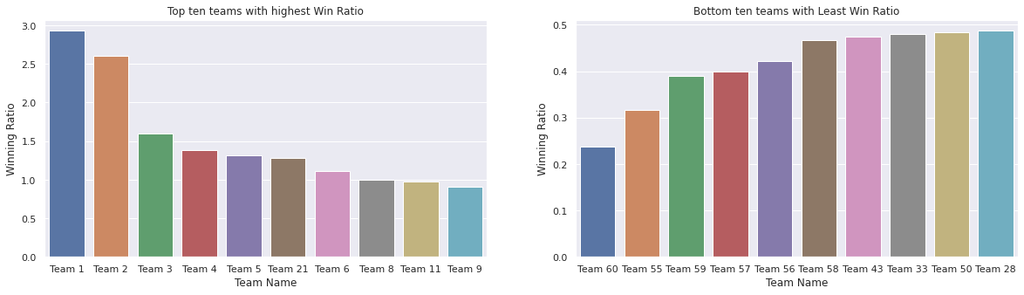

```python
# Top/Bottom ten teams with highest/Least Win Ratio
fig, ax = plt.subplots(figsize=(20, 5))

Win_Ratio = data.sort_values(by=['Win_Ratio'], ascending=False)
Win_Ratio = Win_Ratio.head(10)
sns.set(style="darkgrid")
plt.subplot(1, 2, 1)
sns.barplot(x = Win_Ratio['Team'], y = Win_Ratio['Win_Ratio'])
plt.title('Top ten teams with highest Win Ratio')
plt.ylabel('Winning Ratio')
plt.xlabel('Team Name')

# Top ten teams with highest Win Ratio
Win_Ratio = data.sort_values(by=['Win_Ratio'], ascending=True)
Win_Ratio = Win_Ratio.head(10)
sns.set(style="darkgrid")
plt.subplot(1, 2, 2)
sns.barplot(x = Win_Ratio['Team'], y = Win_Ratio['Win_Ratio'])
plt.title('Bottom ten teams with Least Win Ratio')
plt.ylabel('Winning Ratio')
plt.xlabel('Team Name')
plt.show()
```

Team 1, 2 3, 4 , 5 , 21, 6, 8, 11 an 9 are the Top ten teams with highest Win Ratio.

Team 60, 55, 59, 57, etc are the bottom ten teams with least Win Ratio.

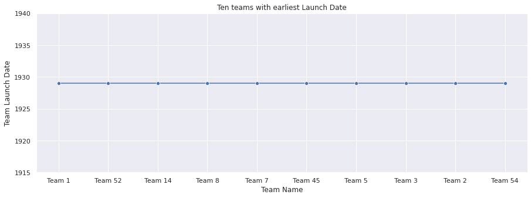

```python
# Ten teams with earliest Launch Date
fig, ax = plt.subplots(figsize=(15, 5))
plt.title('Ten teams with earliest Launch Date')
plt.ylabel('Team Launch Date')
plt.xlabel('Team Name')
Team_Launch = data.sort_values(by = ['TeamLaunch'], ascending=True)
Team_Launch = Team_Launch.head(10)
sns.set_style("whitegrid")
plot = sns.lineplot(x='Team', y='TeamLaunch', data=Team_Launch, marker = 'o')
plot.set(ylim=(1915, 1940))
plt.show()
```

Team 1, 52, 14, 8, 7, 45, 5, 3, 2 & 54 have all been launched very early and in the same year 1929.

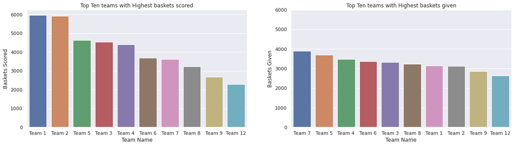

```python
# Top Ten teams with Highest baskets scored/Given
fig, ax = plt.subplots(figsize=(20, 5))
sns.set(style="darkgrid")

BasketScored = data.sort_values(by = ['BasketScored'], ascending=False)
BasketScored = BasketScored.head(10)
plt.subplot(1, 2, 1)
plot = sns.barplot(x = BasketScored['Team'], y = BasketScored['BasketScored'])
plt.title  ('Top Ten teams with Highest baskets scored')
plt.ylabel('Baskets Scored')
plt.xlabel('Team Name')

BasketGiven = data.sort_values(by = ['BasketGiven'], ascending=False)
BasketGiven = BasketGiven.head(10)
plt.subplot(1, 2, 2)
plot = sns.barplot(x = BasketGiven['Team'], y = BasketGiven['BasketGiven'])
plot.set(ylim=(0, 6000))
plt.title  ('Top Ten teams with Highest baskets given')
plt.ylabel('Baskets Given')
plt.xlabel('Team Name')

plt.show()
```

Team 1 & 2 have high Basket Scores.

Teams 7 has more Baskets Given than scored. Hence they do not appear in Top 10 performers.

Teams 5 & 4 have slightly more Baskets scored than given.

Teams 6, 8 , 9 have almost same Baskets scored and given values.

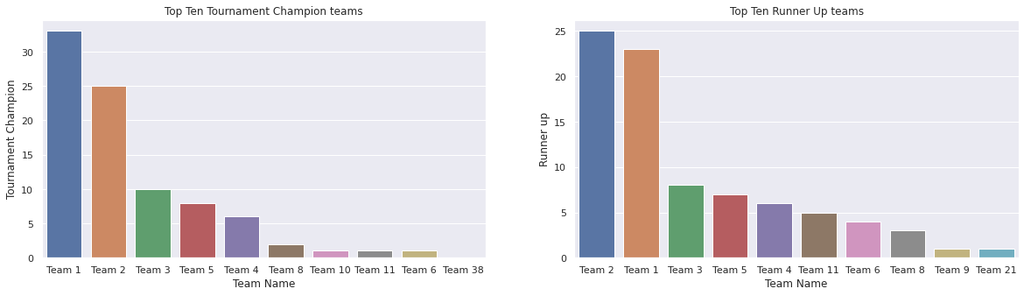

```python
# Top Ten TournamentChampion & Runner-Up teams
fig, ax = plt.subplots(figsize=(20, 5))
sns.set(style="darkgrid")

TournamentChampion = data.sort_values(by = ['TournamentChampion'], ascending=False)
TournamentChampion = TournamentChampion.head(10)
plt.subplot(1, 2, 1)
plot = sns.barplot(x = TournamentChampion['Team'], y = TournamentChampion['TournamentChampion'])
plt.title  ('Top Ten Tournament Champion teams')
plt.ylabel('Tournament Champion')
plt.xlabel('Team Name')

Runner_up = data.sort_values(by = ["Runner-up"], ascending=False)
Runner_up = Runner_up.head(10)
plt.subplot(1, 2, 2)
plot = sns.barplot(x = Runner_up['Team'], y = Runner_up['Runner-up'])
plt.title  ('Top Ten Runner Up teams')
plt.ylabel('Runner up')
plt.xlabel('Team Name')
plt.show()
```

Team 1 & 2 have either been Winners or RunnerUps most of the times.

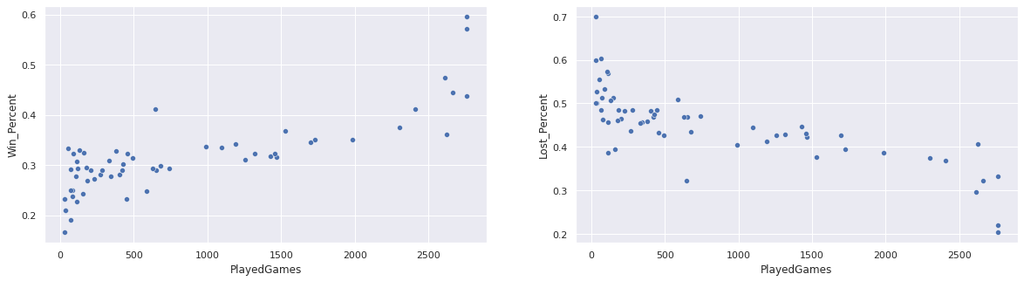

```python
fig, ax = plt.subplots(figsize=(20, 5))
sns.set(style="darkgrid")
plt.subplot(1, 2, 1)
plot = sns.scatterplot(x = data['PlayedGames'], y = data['Win_Percent']);

plt.subplot(1, 2, 2)
plot = sns.scatterplot(x = data['PlayedGames'], y = data['Lost_Percent']);
plt.show()
```

From above graphs, it is clearly seen that there is a strong correlation between Number of games played and Win/Loss Percentage. Couple of exceptions are seen.

If the team plays more number of games, the percentage of their winning is increasing.

If the team plays more number of games, the percentage of their loss is decreasing.

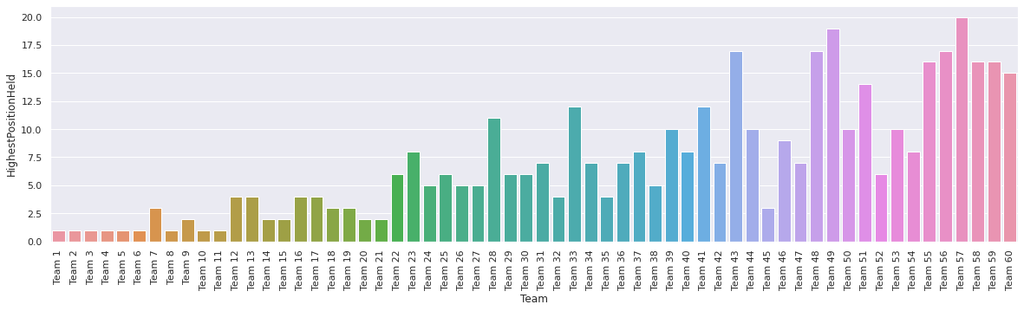

```python
fig, ax = plt.subplots(figsize=(20, 5))
sns.set(style="darkgrid")
plot = sns.barplot(x = data['Team'], y = data['HighestPositionHeld'])
plt.xticks(rotation=90)
```

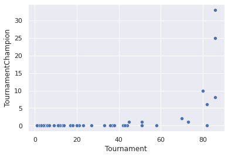

```python
# Relation between number of tournaments played and tournament championships
sns.scatterplot(data=data, x="Tournament", y="TournamentChampion");
```

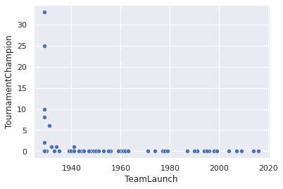

```python
# Relation between Team launch year and tournament championships
sns.scatterplot(data=data, x="TeamLaunch", y="TournamentChampion");
```

```python
# In order to recommend to Company X as to which team to approach for deal since some of the older teams are already in contract with competitors.
# Lets look at Runner Up column and see who all won atleast once and less than 5
Runner_Up = data[data['Runner-up'] >= 1]
Runner_Up = Runner_Up[Runner_Up['Runner-up'] <= 5]
Runner_Up = Runner_Up.sort_values('Win_Percent',ascending=False)

Runner_Up.head(10)
```

|  | Team | Tournament | Score | PlayedGames | WonGames | DrawnGames | LostGames | BasketScored | BasketGiven | TournamentChampion | Runner-up | TeamLaunch | HighestPositionHeld | Win_Percent | Lost_Percent | Win_Ratio | Basket_Diff |
| --- | --- | --- | --- | --- | --- | --- | --- | --- | --- | --- | --- | --- | --- | --- | --- | --- | --- |
| 20 | Team 21 | 17 | 970 | 646 | 266 | 172 | 208 | 892 | 789 | 0 | 1 | 1998 | 2 | 0.411765 | 0.321981 | 1.278846 | 103 |
| 5 | Team 6 | 73 | 2819 | 2408 | 990 | 531 | 887 | 3680 | 3373 | 1 | 4 | 1934 | 1 | 0.411130 | 0.368355 | 1.116122 | 307 |
| 7 | Team 8 | 70 | 2573 | 2302 | 864 | 577 | 861 | 3228 | 3230 | 2 | 3 | 1929 | 1 | 0.375326 | 0.374023 | 1.003484 | -2 |
| 10 | Team 11 | 45 | 1814 | 1530 | 563 | 392 | 575 | 2052 | 2188 | 1 | 5 | 1941 | 1 | 0.367974 | 0.375817 | 0.979130 | -136 |
| 8 | Team 9 | 58 | 2109 | 1986 | 698 | 522 | 766 | 2683 | 2847 | 0 | 1 | 1939 | 2 | 0.351460 | 0.385700 | 0.911227 | -164 |
| 19 | Team 20 | 33 | 1020 | 1096 | 367 | 242 | 487 | 1347 | 1746 | 0 | 1 | 1951 | 2 | 0.334854 | 0.444343 | 0.753593 | -399 |
| 14 | Team 15 | 43 | 1389 | 1458 | 471 | 358 | 629 | 1753 | 2152 | 0 | 1 | 1944 | 2 | 0.323045 | 0.431413 | 0.748808 | -399 |
| 13 | Team 14 | 44 | 1416 | 1428 | 453 | 336 | 639 | 1843 | 2368 | 0 | 1 | 1929 | 2 | 0.317227 | 0.447479 | 0.708920 | -525 |

Considering TeamLaunch Year, Win Percent, BasketDiff and the fact that they have been Runner Up, I'd recommend Company X to approach Team Number 21, 6, 8, 11 and 9 to get a winning deal.

## **3.** Please include any improvements or suggestions to the association management on quality, quantity, variety, velocity, veracity etc. on the data points collected by the association to perform a better data analysis in future. At-least 1 suggestion for each point.

Quality - Use 0 instead of '-' to represent any unknown numbers/counts.The date column is only for Team Launch Year. Only the Launch year needs to be mentioned instead of range. Only one standard date format can be used.Instances were found where the entries were junk or not filled properly.

Quantity - Team performance in each year since it started in the championship should be provided for better analysis.

Variety - Other factors like age of players, how much marketing, staff and advertisement attribute of winning tournament championships.

Velocity - year wise data will be more beneficial.

Veracity - More information on how this data was gathered will help.

# **PART C**

• DOMAIN: Startup ecosystem

• CONTEXT: Company X is a EU online publisher focusing on the startups industry. The company specifically reports on the business related to technology news, analysis of emerging trends and profiling of new tech businesses and products. Their event i.e. Startup Battlefield is the world’s pre-eminent startup competition. Startup Battlefield features 15-30 top early stage startups pitching top judges in front of a vast live audience, present in person and online.

• DATA DESCRIPTION: CompanyX_EU.csv - Each row in the dataset is a Start-up company and the columns describe the company.

• DATA DICTIONARY:

1. Startup: Name of the company
2. Product: Actual product
3. Funding: Funds raised by the company in USD
4. Event: The event the company participated in
5. Result: Described by Contestant, Finalist, Audience choice, Winner or Runner up
6. OperatingState: Current status of the company, Operating ,Closed, Acquired or IPO *Dataset has been downloaded from the internet. All the credit for the dataset goes to the original creator of the data.

• PROJECT OBJECTIVE: Analyse the data of the various companies from the given dataset and perform the tasks that are specified in the below steps. Draw insights from the various attributes that are present in the dataset, plot distributions, state hypotheses and draw conclusions from the dataset.

```python
#Import all necessary libraries
import numpy as np
import pandas as pd
import matplotlib.pyplot as plt
```

## **1.** Read the CSV file.

```python
data = pd.read_csv("DS - Part3 - CompanyX_EU.csv")
```

## **2A.** Check the datatypes of each attribute.

```python
# Keep a copy of the original dataframe
original_data = data.copy(deep=True)
```

```python
data.head()
```

|  | Startup | Product | Funding | Event | Result | OperatingState |
| --- | --- | --- | --- | --- | --- | --- |
| 0 | 2600Hz | 2600hz.com | NaN | Disrupt SF 2013 | Contestant | Operating |
| 1 | 3DLT | 3dlt.com | $630K | Disrupt NYC 2013 | Contestant | Closed |
| 2 | 3DPrinterOS | 3dprinteros.com | NaN | Disrupt SF 2016 | Contestant | Operating |
| 3 | 3Dprintler | 3dprintler.com | $1M | Disrupt NY 2016 | Audience choice | Operating |
| 4 | 42 Technologies | 42technologies.com | NaN | Disrupt NYC 2013 | Contestant | Operating |

```python
original_data.head()
```

|  | Startup | Product | Funding | Event | Result | OperatingState |
| --- | --- | --- | --- | --- | --- | --- |
| 0 | 2600Hz | 2600hz.com | NaN | Disrupt SF 2013 | Contestant | Operating |
| 1 | 3DLT | 3dlt.com | $630K | Disrupt NYC 2013 | Contestant | Closed |
| 2 | 3DPrinterOS | 3dprinteros.com | NaN | Disrupt SF 2016 | Contestant | Operating |
| 3 | 3Dprintler | 3dprintler.com | $1M | Disrupt NY 2016 | Audience choice | Operating |
| 4 | 42 Technologies | 42technologies.com | NaN | Disrupt NYC 2013 | Contestant | Operating |

```python
data.info()
```

```
<class 'pandas.core.frame.DataFrame'>
RangeIndex: 662 entries, 0 to 661
Data columns (total 6 columns):
 #   Column          Non-Null Count  Dtype
---  ------          --------------  -----
 0   Startup         662 non-null    object
 1   Product         656 non-null    object
 2   Funding         448 non-null    object
 3   Event           662 non-null    object
 4   Result          662 non-null    object
 5   OperatingState  662 non-null    object
dtypes: object(6)
memory usage: 31.2+ KB
```

**Observations:**

We have all 6 fields with 'object' datatype.

```python
data.describe()
```

|  | Startup | Product | Funding | Event | Result | OperatingState |
| --- | --- | --- | --- | --- | --- | --- |
| count | 662 | 656 | 448 | 662 | 662 | 662 |
| unique | 662 | 656 | 240 | 26 | 5 | 4 |
| top | 2600Hz | 2600hz.com | $1M | TC50 2008 | Contestant | Operating |
| freq | 1 | 1 | 17 | 52 | 488 | 465 |

## **2B.** Check for null values in the attributes.

```python
data.isnull().sum()
```

```
Startup             0
Product             6
Funding           214
Event               0
Result              0
OperatingState      0
dtype: int64
```

**Observations:**

We observe many missing values in Funding column.

6 values are missing in Product column.

## **3A.** Drop the null values.

```python
# Drop the null values
data.dropna(inplace=True)
data.info()
```

```
<class 'pandas.core.frame.DataFrame'>
Int64Index: 446 entries, 1 to 661
Data columns (total 6 columns):
 #   Column          Non-Null Count  Dtype
---  ------          --------------  -----
 0   Startup         446 non-null    object
 1   Product         446 non-null    object
 2   Funding         446 non-null    object
 3   Event           446 non-null    object
 4   Result          446 non-null    object
 5   OperatingState  446 non-null    object
dtypes: object(6)
memory usage: 24.4+ KB
```

**Observations:**

No more Null values seen in data set.

## **3B.** Convert the ‘Funding’ features to a numerical value.

```python
# Remove $ and delimiter chars
def del_char(x):
    if isinstance(x, str):
        return(x.replace('$', '').replace(',', ''))
    return(x)

data['Funding'] = data['Funding'].apply(del_char)
data.head()
```

|  | Startup | Product | Funding | Event | Result | OperatingState |
| --- | --- | --- | --- | --- | --- | --- |
| 1 | 3DLT | 3dlt.com | 630K | Disrupt NYC 2013 | Contestant | Closed |
| 3 | 3Dprintler | 3dprintler.com | 1M | Disrupt NY 2016 | Audience choice | Operating |
| 5 | 5to1 | 5to1.com | 19.3M | TC50 2009 | Contestant | Acquired |
| 6 | 8 Securities | 8securities.com | 29M | Disrupt Beijing 2011 | Finalist | Operating |
| 10 | AdhereTech | adheretech.com | 1.8M | Hardware Battlefield 2014 | Contestant | Operating |

```python
# Covert all values into same unit.
def str_to_num(x):
    if type(x) == float or type(x) == int:
        return x
    if 'K' in x:
        if len(x) > 1:
            return float(x.replace('K', '')) * 1000
        return 1000
    if 'M' in x:
        if len(x) > 1:
            return float(x.replace('M', '')) * 1000000
        return 1000000
    if 'B' in x:
        return float(x.replace('B', '')) * 1000000000
    return 0

data['Funding'] = data['Funding'].apply(str_to_num)
data.head()
```

|  | Startup | Product | Funding | Event | Result | OperatingState |
| --- | --- | --- | --- | --- | --- | --- |
| 1 | 3DLT | 3dlt.com | 630000.0 | Disrupt NYC 2013 | Contestant | Closed |
| 3 | 3Dprintler | 3dprintler.com | 1000000.0 | Disrupt NY 2016 | Audience choice | Operating |
| 5 | 5to1 | 5to1.com | 19300000.0 | TC50 2009 | Contestant | Acquired |
| 6 | 8 Securities | 8securities.com | 29000000.0 | Disrupt Beijing 2011 | Finalist | Operating |
| 10 | AdhereTech | adheretech.com | 1800000.0 | Hardware Battlefield 2014 | Contestant | Operating |

```python
data['Funding'].apply(type).value_counts()
```

```
<class 'float'>    446
Name: Funding, dtype: int64
```

**Observations:**

Make sure all entries are in float and properly converted.

```python
data['Funding'] = data['Funding'].apply(pd.to_numeric)
data.info()
```

```
<class 'pandas.core.frame.DataFrame'>
Int64Index: 446 entries, 1 to 661
Data columns (total 6 columns):
 #   Column          Non-Null Count  Dtype
---  ------          --------------  -----
 0   Startup         446 non-null    object
 1   Product         446 non-null    object
 2   Funding         446 non-null    float64
 3   Event           446 non-null    object
 4   Result          446 non-null    object
 5   OperatingState  446 non-null    object
dtypes: float64(1), object(5)
memory usage: 24.4+ KB
```

**Observations:**

Funding Column datatype is now numeric and properly converted.

## **3C.** Plot box plot for funds in million.

```python
# Need to add a new column Funds_in_Million
data['Funds_in_Million'] = data['Funding']/1000000
data.info()
```

```
<class 'pandas.core.frame.DataFrame'>
Int64Index: 446 entries, 1 to 661
Data columns (total 7 columns):
 #   Column            Non-Null Count  Dtype
---  ------            --------------  -----
 0   Startup           446 non-null    object
 1   Product           446 non-null    object
 2   Funding           446 non-null    float64
 3   Event             446 non-null    object
 4   Result            446 non-null    object
 5   OperatingState    446 non-null    object
 6   Funds_in_Million  446 non-null    float64
dtypes: float64(2), object(5)
memory usage: 27.9+ KB
```

```python
data.head()
```

|  | Startup | Product | Funding | Event | Result | OperatingState | Funds_in_Million |
| --- | --- | --- | --- | --- | --- | --- | --- |
| 1 | 3DLT | 3dlt.com | 630000.0 | Disrupt NYC 2013 | Contestant | Closed | 0.63 |
| 3 | 3Dprintler | 3dprintler.com | 1000000.0 | Disrupt NY 2016 | Audience choice | Operating | 1.00 |
| 5 | 5to1 | 5to1.com | 19300000.0 | TC50 2009 | Contestant | Acquired | 19.30 |
| 6 | 8 Securities | 8securities.com | 29000000.0 | Disrupt Beijing 2011 | Finalist | Operating | 29.00 |
| 10 | AdhereTech | adheretech.com | 1800000.0 | Hardware Battlefield 2014 | Contestant | Operating | 1.80 |

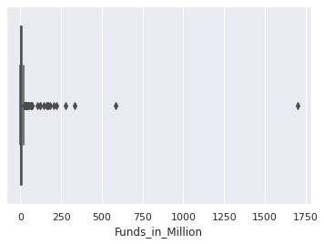

```python
sns.boxplot(x = data["Funds_in_Million"]);
```

**Observations:**

There are many outliers in the box plot

## **3D.** Check the number of outliers greater than the upper fence.

```python
data.describe()
```

|  | Funding | Funds_in_Million |
| --- | --- | --- |
| count | 4.460000e+02 | 446.000000 |
| mean | 1.724149e+07 | 17.241489 |
| std | 9.048371e+07 | 90.483710 |
| min | 5.000000e+03 | 0.005000 |
| 25% | 7.452500e+05 | 0.745250 |
| 50% | 2.200000e+06 | 2.200000 |
| 75% | 9.475000e+06 | 9.475000 |
| max | 1.700000e+09 | 1700.000000 |

```python
IQR = data['Funds_in_Million'].quantile(0.75) - data['Funds_in_Million'].quantile(0.25)
print("IQR = ", IQR)
upper_fence = data['Funds_in_Million'].quantile(0.75) + (1.5 * IQR)
print("Upper Fence = ", upper_fence)
```

```
IQR =  8.72975
Upper Fence =  22.569625
```

```python
# Count the number of outliers greater than Upper fence
data[data['Funds_in_Million'] > upper_fence].info()
```

```
<class 'pandas.core.frame.DataFrame'>
Int64Index: 60 entries, 6 to 661
Data columns (total 7 columns):
 #   Column            Non-Null Count  Dtype
---  ------            --------------  -----
 0   Startup           60 non-null     object
 1   Product           60 non-null     object
 2   Funding           60 non-null     float64
 3   Event             60 non-null     object
 4   Result            60 non-null     object
 5   OperatingState    60 non-null     object
 6   Funds_in_Million  60 non-null     float64
dtypes: float64(2), object(5)
memory usage: 3.8+ KB
```

**Observations:**

There are 60 outliers for Funds_in_Million greater than the upper fence.

```python
import plotly.express as px
fig = px.box(data, x = "Funds_in_Million", points="outliers")
fig.show()
```

[interactive chart not shown]

```python
# Remove the Outliers and compare
# Upper Fence =  22.569625

# Lets create a copy of the DataFrame
Data_Outliers_rem = data.copy(deep=True)
Data_Outliers_rem = Data_Outliers_rem[Data_Outliers_rem['Funds_in_Million'] <= upper_fence].copy()
```

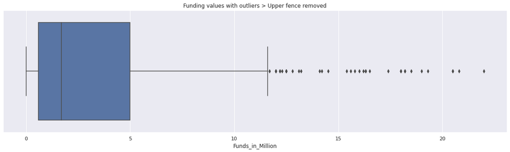

```python
# Boxplot for the values where outliers on a higher side are removed

fig, ax = plt.subplots(figsize=(20, 5))
sns.boxplot(x = Data_Outliers_rem["Funds_in_Million"]);
plt.title("Funding values with outliers > Upper fence removed")
plt.show()
```

## **3E.** Check frequency of the OperatingState features classes.

```python
count = data.groupby('OperatingState')["OperatingState"].count()
print(count)
```

```
OperatingState
Acquired      66
Closed        57
Ipo            4
Operating    319
Name: OperatingState, dtype: int64
```

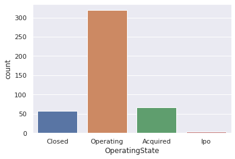

```python
sns.countplot(data = data, x = data['OperatingState']);
```

## **4A.** Is there any significant difference between Funds raised by companies that are still operating vs companies that closed down?

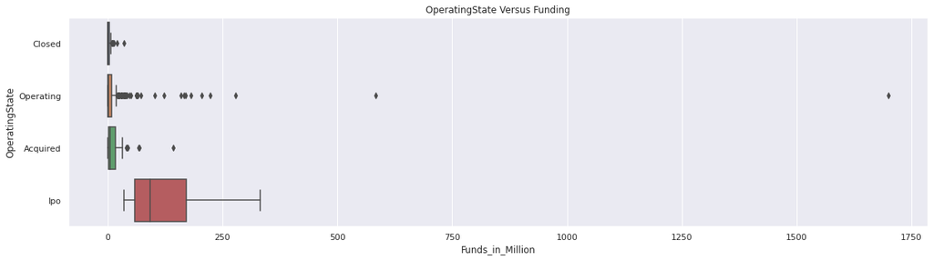

```python
fig, ax = plt.subplots(figsize=(20, 5))
sns.boxplot(data= data, y= 'OperatingState', x= 'Funds_in_Million');
plt.title('OperatingState Versus Funding')
plt.show()
```

```python
data.groupby(['OperatingState']).sum()
```

| OperatingState | Funding | Funds_in_Million |
| --- | --- | --- |
| Acquired | 8.720510e+08 | 872.0510 |
| Closed | 1.857157e+08 | 185.7157 |
| Ipo | 5.511000e+08 | 551.1000 |
| Operating | 6.080837e+09 | 6080.8372 |

**Observations:**

The Funds in million has lot of outliers for companies which are operating.

From the above table, it is observed that there is a numerical difference between Funds raised by companies that are still operating vs companies that closed down.